# One Way ANOVA

Kristopher Kyle

3/22/2019

## Examining differences between more than two groups

When we want to examine differences between two independent groups, a t-test or Man-Whitney U test are the most appropriate to use. If we have more than two independent groups, however, it is not appropriate to use these tests. Instead, we should use an Analysis of Variance (ANOVA) test or one of the non-parametric alternatives.

### Assumptions of One-Way ANOVA

To use an ANOVA, our data must meet the following assunptions:

1. The groups are independent (and do not include repeated measures)
2. There is a normal distribution of values in each group
3. The variance in each group is equal (this is call homogeneity of variance)

Note that we will be double checking some of these assumptions after conducting the analysis due to the way that particular R packages have been written.

### Description of sample data

In this tutorial, we will be looking at essays written by individuals at three different levels of lexical proficiency (Beginner, Intermediate, and High). We will also be looking at the average meaningfulness score for all words in each text. Meaningfulness scores are one way of determining how many concepts a particular word might be related to (e.g., the word “food” would be more “meaningful” than “zygote” because it could be used in more semantic contexts). We will be determining whether there are any differences in average meaningfulness scores based on lexical proficiency group.

```r
mydata <- read.csv("data/anova_sample.csv", header = TRUE)
summary(mydata)
```

```
##    filenames     Proficiency  Frequent_Trigram_Proportion
##  1.txt  :  1   Beginner: 61   Min.   :0.0480
##  10.txt :  1   High    : 68   1st Qu.:0.1390
##  100.txt:  1   Int     :111   Median :0.1931
##  101.txt:  1                  Mean   :0.1930
##  102.txt:  1                  3rd Qu.:0.2427
##  103.txt:  1                  Max.   :0.3623
##  (Other):234
##  Meaningfulness_AW Register_Range_CW L1_Word_Reaction_Time Concreteness_AW
##  Min.   :325.4     Min.   :10.23     Min.   :594.3         Min.   :2.143
##  1st Qu.:363.7     1st Qu.:13.13     1st Qu.:610.5         1st Qu.:2.491
##  Median :375.4     Median :13.57     Median :615.9         Median :2.619
##  Mean   :376.1     Mean   :13.52     Mean   :616.4         Mean   :2.644
##  3rd Qu.:386.3     3rd Qu.:13.93     3rd Qu.:621.4         3rd Qu.:2.772
##  Max.   :453.7     Max.   :14.86     Max.   :655.6         Max.   :3.539
##
```

### Visualizing the data

First, we can create density plots to look at the distribution of each group. These density plots suggest that the data is roughly normal and that the variance is roughly equal.

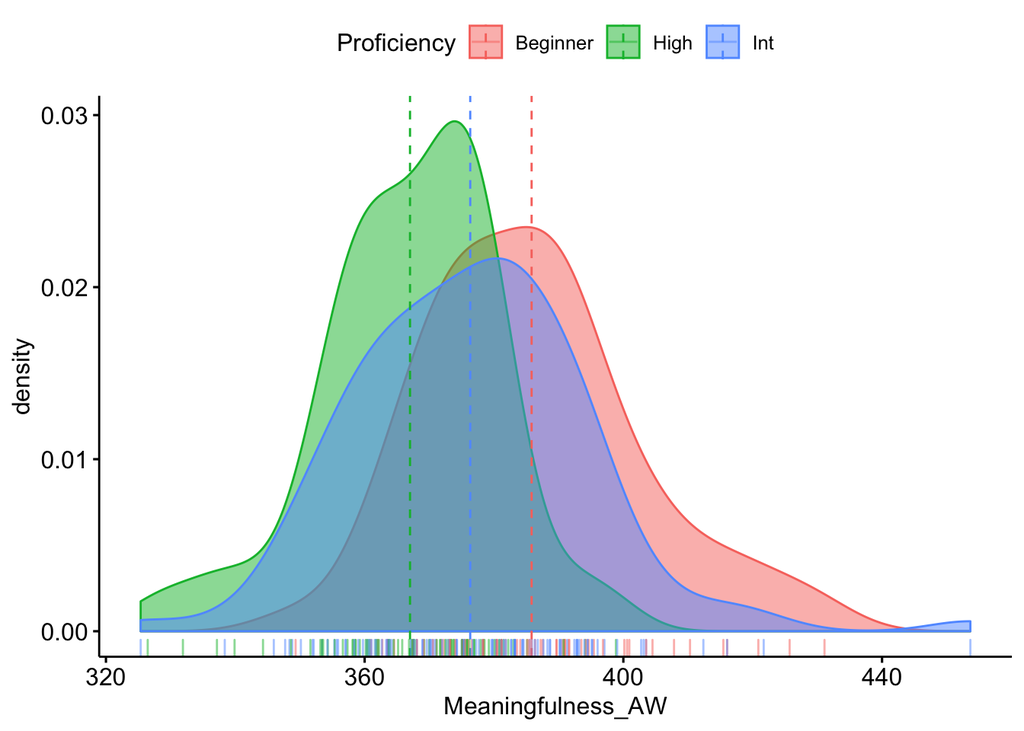

```r
library("ggpubr")
ggdensity(mydata, x = "Meaningfulness_AW",
          add = "mean", rug = TRUE,
          color = "Proficiency", fill = "Proficiency")
```

Second, we will generate some boxplots. These boxplots support the notion that the variance is roughly equal, and also suggests that there may be meaningful differences between the groups.

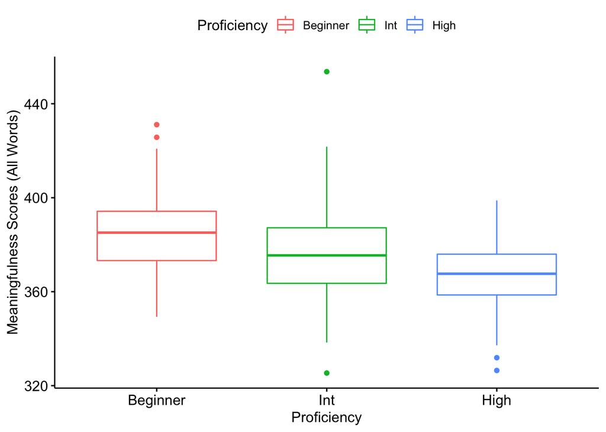

```r
ggboxplot(mydata, x = "Proficiency", y = "Meaningfulness_AW",
          color = "Proficiency",
          order = c("Beginner", "Int", "High"),
          ylab = "Meaningfulness Scores (All Words)", xlab = "Proficiency")
```

Third, we can look at mean plots, which further suggest that there may be differences between the groups.

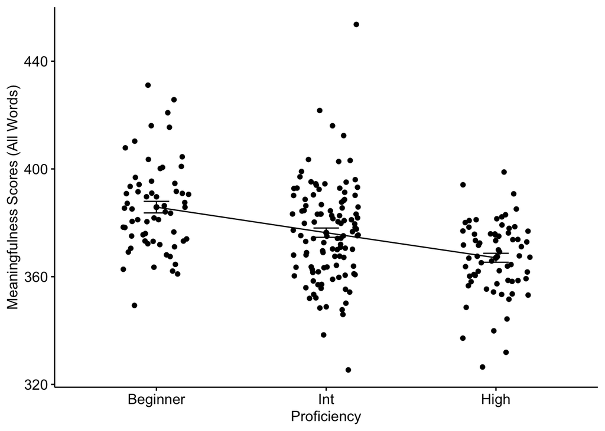

```r
ggline(mydata, x = "Proficiency", y = "Meaningfulness_AW",
       add = c("mean_se", "jitter"),
       order = c("Beginner", "Int", "High"),
       ylab = "Meaningfulness Scores (All Words)", xlab = "Proficiency")
```

### Conducting the analysis

First, we will fit a linear regression to demonstrate that an ANOVA and a linear regression are related analyses. Then, we will conduct an ANOVA with post-hoc tests and provide some non-parametric alternatives.

### Getting descriptive statistics

First, we will get our descriptive statistics.

```r
library(psych)
describeBy(mydata$Meaningfulness_AW,mydata$Proficiency)
```

```
##
##  Descriptive statistics by group
## group: Beginner
##    vars  n   mean    sd median trimmed   mad    min   max range skew
## X1    1 61 385.82 16.68 385.13  384.74 15.29 349.32 431.1 81.78 0.54
##    kurtosis   se
## X1     0.11 2.14
## --------------------------------------------------------
## group: High
##    vars  n   mean    sd median trimmed   mad    min    max range  skew
## X1    1 68 367.01 13.73 367.64  367.76 13.04 326.46 398.85 72.39 -0.52
##    kurtosis   se
## X1     0.55 1.67
## --------------------------------------------------------
## group: Int
##    vars   n   mean    sd median trimmed   mad    min    max  range skew
## X1    1 111 376.32 18.18 375.45   375.9 17.73 325.37 453.66 128.29 0.57
##    kurtosis   se
## X1     2.15 1.73
```

#### Fitting a linear regression

First, we will run a linear model (i.e., a regression) for comparison.

```r
regr_model <- lm(Meaningfulness_AW~Proficiency, data = mydata) #note that for this to work, our dependent variable has to be numeric
summary(regr_model)
```

```
##
## Call:
## lm(formula = Meaningfulness_AW ~ Proficiency, data = mydata)
##
## Residuals:
##     Min      1Q  Median      3Q     Max
## -50.956 -11.678   0.088   9.564  77.330
##
## Coefficients:
##                 Estimate Std. Error t value Pr(>|t|)
## (Intercept)      385.816      2.131 181.007  < 2e-16 ***
## ProficiencyHigh  -18.802      2.936  -6.404 8.04e-10 ***
## ProficiencyInt    -9.491      2.653  -3.577 0.000421 ***
## ---
## Signif. codes:  0 '***' 0.001 '**' 0.01 '*' 0.05 '.' 0.1 ' ' 1
##
## Residual standard error: 16.65 on 237 degrees of freedom
## Multiple R-squared:  0.1476, Adjusted R-squared:  0.1405
## F-statistic: 20.53 on 2 and 237 DF,  p-value: 6.005e-09
```

These results suggest that there is a linear relationship between Proficiency and Meaninfulness scores,

#### Conducting an ANOVA

Next, we will run an ANOVA, which will tell us whether there are significant differences between any of the groups:

```r
library("lsr")
anova_model <- aov(Meaningfulness_AW~Proficiency, data = mydata)
summary(anova_model)
```

```
##              Df Sum Sq Mean Sq F value   Pr(>F)
## Proficiency   2  11377    5689   20.53 6.01e-09 ***
## Residuals   237  65682     277
## ---
## Signif. codes:  0 '***' 0.001 '**' 0.01 '*' 0.05 '.' 0.1 ' ' 1
```

```r
etaSquared(anova_model, type = 3)
```

```
##               eta.sq eta.sq.part
## Proficiency 0.147645    0.147645
```

The results indicate that there are indeed differences between our groups (p = .000000006), and that these differences are meaningful (eta squared = 0.148 - note that this is the same as our linear regression), but they don’t tell us where those differences are.

#### Conducting pairwise comparisons

To figure out where the differences are, we have to run pairwise comparisons. In this case, we will conduct Tukey HSD (Honest Significant Differences) test, which nicely balances the potential for Type I and Type II errors. As we see below, there are significant differences between each of our groups. Note that the observed differences relate to the linear regression model above.

```r
TukeyHSD(anova_model)
```

```
##   Tukey multiple comparisons of means
##     95% family-wise confidence level
##
## Fit: aov(formula = Meaningfulness_AW ~ Proficiency, data = mydata)
##
## $Proficiency
##                     diff       lwr        upr     p adj
## High-Beginner -18.801696 -25.72585 -11.877543 0.0000000
## Int-Beginner   -9.491098 -15.74900  -3.233192 0.0012211
## Int-High        9.310598   3.26413  15.357066 0.0010025
```

To get an effect size for each contrast, we will have to do a little more work. Below, we create a new dataframe using the “filter” and “select” functions of dplyr to select only rows that have a Proficiency value of “Beginner” or “Int” (using filter), and only the columns Proficiency and Meaningfulness_AW. We then use the function “cohen.d” in the psych package to calculat the effect size between the “Beginner” and “Int” groups. As we see below, the effect between these groups is .54, which represents a medium effect.

```r
library(dplyr)
#create new df with only Beginner and Int
mydata_effs_BI <- mydata %>%
  filter(Proficiency == "Beginner" | Proficiency == "Int") %>%
  select(Proficiency, Meaningfulness_AW)
summary(mydata_effs_BI)
```

```
##    Proficiency  Meaningfulness_AW
##  Beginner: 61   Min.   :325.4
##  High    :  0   1st Qu.:368.1
##  Int     :111   Median :380.0
##                 Mean   :379.7
##                 3rd Qu.:390.6
##                 Max.   :453.7
```

```r
#create new df with only Beginner and High
mydata_effs_BH <- mydata %>%
  filter(Proficiency == "Beginner" | Proficiency == "High") %>%
  select(Proficiency, Meaningfulness_AW)
summary(mydata_effs_BH)
```

```
##    Proficiency Meaningfulness_AW
##  Beginner:61   Min.   :326.5
##  High    :68   1st Qu.:364.5
##  Int     : 0   Median :375.1
##                Mean   :375.9
##                3rd Qu.:385.4
##                Max.   :431.1
```

```r
#create new df with only Int and High
mydata_effs_IH <- mydata %>%
  filter(Proficiency == "Int" | Proficiency == "High") %>%
  select(Proficiency, Meaningfulness_AW)
summary(mydata_effs_IH)
```

```
##    Proficiency  Meaningfulness_AW
##  Beginner:  0   Min.   :325.4
##  High    : 68   1st Qu.:361.3
##  Int     :111   Median :373.1
##                 Mean   :372.8
##                 3rd Qu.:382.8
##                 Max.   :453.7
```

```r
#note, this uses the psych package:
cohen.d(mydata_effs_BI,"Proficiency")
```

```
## Call: cohen.d(x = mydata_effs_BI, group = "Proficiency")
## Cohen d statistic of difference between two means
##                   lower effect upper
## Meaningfulness_AW -0.87  -0.54 -0.21
##
## Multivariate (Mahalanobis) distance between groups
## [1] 0.54
## r equivalent of difference between two means
## Meaningfulness_AW
##             -0.25
```

To get the effect sizes for the rest of the contrasts, we repeat this process with the other group combinations (“Beginner” to “High” and “Int” to “High”).

```r
#create new df with only Beginner and High
mydata_effs_BH <- mydata %>%
  filter(Proficiency == "Beginner" | Proficiency == "High") %>%
  select(Proficiency, Meaningfulness_AW)

#create new df with only Int and High
mydata_effs_IH <- mydata %>%
  filter(Proficiency == "Int" | Proficiency == "High") %>%
  select(Proficiency, Meaningfulness_AW)

#note, this uses the psych package:
cohen.d(mydata_effs_BH,"Proficiency")
```

```
## Call: cohen.d(x = mydata_effs_BH, group = "Proficiency")
## Cohen d statistic of difference between two means
##                   lower effect upper
## Meaningfulness_AW  -1.7   -1.2 -0.83
##
## Multivariate (Mahalanobis) distance between groups
## [1] 1.2
## r equivalent of difference between two means
## Meaningfulness_AW
##             -0.53
```

```r
cohen.d(mydata_effs_IH,"Proficiency")
```

```
## Call: cohen.d(x = mydata_effs_IH, group = "Proficiency")
## Cohen d statistic of difference between two means
##                   lower effect upper
## Meaningfulness_AW  0.24   0.56  0.88
##
## Multivariate (Mahalanobis) distance between groups
## [1] 0.56
## r equivalent of difference between two means
## Meaningfulness_AW
##              0.26
```

### Checking assumptions

#### Homogeneity of variance

First, we can visually check the relationship between the residuals (e.g., the error) and the fitted values to ensure that there isn’t a relationship between these two. As we see below, our line is flat, indicating that there is not a relationship between these.

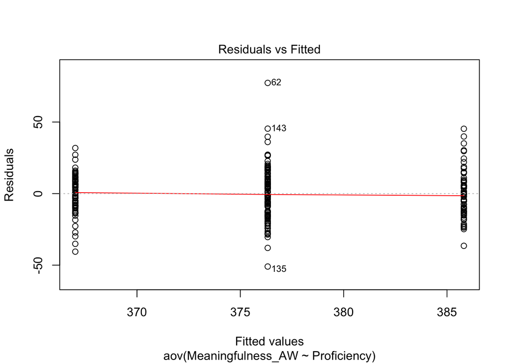

```r
plot(anova_model,1)
```

Second, we can conduct Levene’s test, which determines the degree to which the variance differs across groups.

```r
library(car)
leveneTest(Meaningfulness_AW~Proficiency, data = mydata)
```

```
## Levene's Test for Homogeneity of Variance (center = median)
##        Df F value Pr(>F)
## group   2  2.0676 0.1288
##       237
```

The test for homogeneity of variance indicates that there is a 12.88% chance that we would observe the differences in variance if there were no difference. Because this chance is above 5% (p = .05), it can be suggested that the groups have equal variance.

#### What to do if we violate homogeneity of variance

If our groups are normally distributed but violate homogeneity of variance, we can compute the Welch one-way test with Games-Howell post hoc tests. Note that we would still use eta squared as our effect size, which would would generate using the code above.

```r
library(userfriendlyscience)
oneway(mydata$Proficiency, y = mydata$Meaningfulness_AW, posthoc = 'games-howell')
```

```
## ### Oneway Anova for y=Meaningfulness_AW and x=Proficiency (groups: Beginner, High, Int)
##
## Omega squared: 95% CI = [.07; .23], point estimate = .14
## Eta Squared: 95% CI = [.08; .21], point estimate = .15
##
##                                       SS  Df      MS     F     p
## Between groups (error + effect) 11377.45   2 5688.72 20.53 <.001
## Within groups (error only)      65682.01 237  277.14
##
##
## ### Post hoc test: games-howell
##
##                 diff  ci.lo  ci.hi    t     df     p
## High-Beginner -18.80 -25.23 -12.37 6.94 116.56 <.001
## Int-Beginner   -9.49 -16.00  -2.98 3.46 132.96  .002
## Int-High        9.31   3.64  14.98 3.88 169.24 <.001
```

#### Double checking normality using QQ plots

We have already visually checked for normality using density plots. However, we can also check for normality using a Q-Q plot. In this case our data appears to be roughly normally distributed, confirming our visual inspection of the density plots.

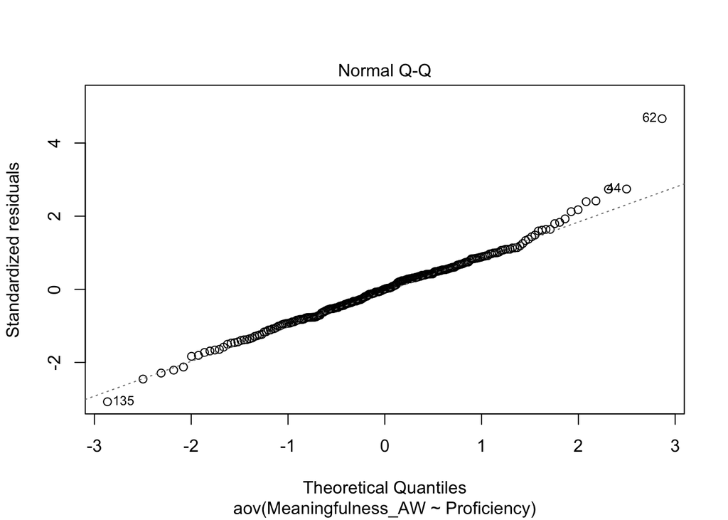

```r
plot(anova_model,2)
```

#### What if my data isn’t normally distributed?

If our data is NOT normally distributed, there are non-parametric alternatives. One of these is the Kruskal-Wallis rank sum test:

```r
kruskal.test(Meaningfulness_AW~Proficiency, data = mydata)
```

```
##
##  Kruskal-Wallis rank sum test
##
## data:  Meaningfulness_AW by Proficiency
## Kruskal-Wallis chi-squared = 36.999, df = 2, p-value = 9.244e-09
```

One option for pairwise comparisons with the Kruskal- Wallis test is the Dunn test:

```r
library(FSA)
dunnTest(Meaningfulness_AW~Proficiency, data = mydata, method = "bh")
```

```
## Dunn (1964) Kruskal-Wallis multiple comparison
```

```
##   p-values adjusted with the Benjamini-Hochberg method.
```

```
##        Comparison         Z      P.unadj        P.adj
## 1 Beginner - High  6.077392 1.221526e-09 3.664578e-09
## 2  Beginner - Int  3.339410 8.395669e-04 8.395669e-04
## 3      High - Int -3.503382 4.593903e-04 6.890855e-04
```